# **Impact of Adiflow on Production and Quality Parameters**

#### Okuo Analytics

### **Introduction**

This report was developed using the Okuo Flow platform, a tool focused on the **centralization**, **integration**, and **transformation** of data related to production and quality in feed plants. Thanks to this platform, it is possible to extract valuable information that facilitates decision-making by simultaneously analyzing production variables (processed tons, production times, and sack-off) and quality variables (temperature, pellet durability, and moisture). This enables **performance optimization** while maintaining high quality standards, reducing friction between production and quality departments, and achieving a smoother and more efficient process.  
In this context, we will use Okuo Flow to provide a statistical understanding of the different parameters measured.

### **Production Measurements by Pellet Machine and Adiflow**

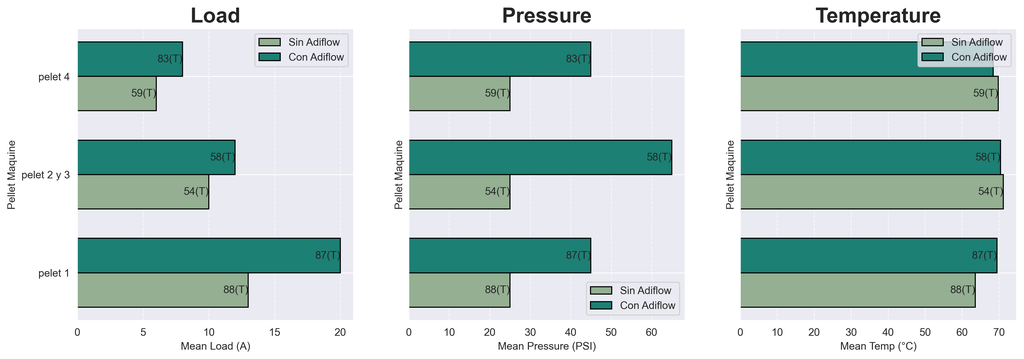

A systematically higher load is observed with the use of Adiflow, as well as higher pressures. In the case of temperature, significant differences are observed only for Pellet machine 1. For the others, differences should be analyzed according to the pelleted diets.

### **Quality Measurements by Pellet Machine and Adiflow**

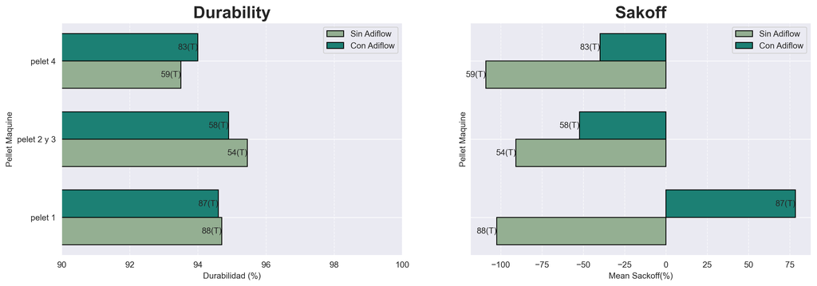

With Adiflow, we improved pellet durability in Pellet machine 4. In Pellet machine 2 and 3, quality decreased by 0.5%. Given the magnitude of the change with and without Adiflow, we do not have statistical significance to guarantee meaningful changes in durability.

### **Change in Initial and Final Moisture with Adiflow**

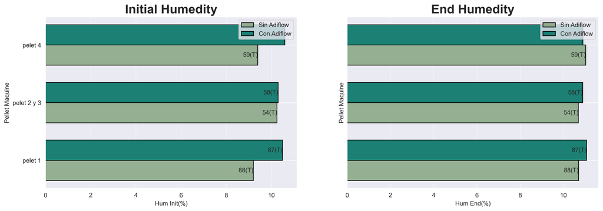

With Adiflow, we consistently have a moisture percentage above 10% before the pelleting process. After the process, moisture levels are maintained.

#### Fecha de elaboración: 26-12-2025

#### [okuo.bio](https://okuo.bio/)